# EasyVisa_Full_Code_Notebook (1)

## Problem Statement

### Business Context

Business communities in the United States are facing high demand for human resources, but one of the constant challenges is identifying and attracting the right talent, which is perhaps the most important element in remaining competitive. Companies in the United States look for hard-working, talented, and qualified individuals both locally as well as abroad.

The Immigration and Nationality Act (INA) of the US permits foreign workers to come to the United States to work on either a temporary or permanent basis. The act also protects US workers against adverse impacts on their wages or working conditions by ensuring US employers' compliance with statutory requirements when they hire foreign workers to fill workforce shortages. The immigration programs are administered by the Office of Foreign Labor Certification (OFLC).

OFLC processes job certification applications for employers seeking to bring foreign workers into the United States and grants certifications in those cases where employers can demonstrate that there are not sufficient US workers available to perform the work at wages that meet or exceed the wage paid for the occupation in the area of intended employment.

### Objective

In FY 2016, the OFLC processed 775,979 employer applications for 1,699,957 positions for temporary and permanent labor certifications. This was a nine percent increase in the overall number of processed applications from the previous year. The process of reviewing every case is becoming a tedious task as the number of applicants is increasing every year.

The increasing number of applicants every year calls for a Machine Learning based solution that can help in shortlisting the candidates having higher chances of VISA approval. OFLC has hired the firm EasyVisa for data-driven solutions. You as a data scientist at EasyVisa have to analyze the data provided and, with the help of a classification model:

- Facilitate the process of visa approvals.
- Recommend a suitable profile for the applicants for whom the visa should be certified or denied based on the drivers that significantly influence the case status.

### Data Description

The data contains the different attributes of employee and the employer. The detailed data dictionary is given below.

- case_id: ID of each visa application
- continent: Information of continent the employee
- education_of_employee: Information of education of the employee
- has_job_experience: Does the employee has any job experience? Y= Yes; N = No
- requires_job_training: Does the employee require any job training? Y = Yes; N = No
- no_of_employees: Number of employees in the employer's company
- yr_of_estab: Year in which the employer's company was established
- region_of_employment: Information of foreign worker's intended region of employment in the US.
- prevailing_wage: Average wage paid to similarly employed workers in a specific occupation in the area of intended employment. The purpose of the prevailing wage is to ensure that the foreign worker is not underpaid compared to other workers offering the same or similar service in the same area of employment.
- unit_of_wage: Unit of prevailing wage. Values include Hourly, Weekly, Monthly, and Yearly.
- full_time_position: Is the position of work full-time? Y = Full Time Position; N = Part Time Position
- case_status: Flag indicating if the Visa was certified or denied

## Installing and Importing the necessary libraries

```python
# Installing the libraries with the specified version.
!pip install numpy==1.26.0 pandas==2.2.2 scikit-learn==1.6 matplotlib==3.8 seaborn==0.13.1 xgboost==2.0.3 -q --user --no-warn-script-location
```

**Note**: *After running the above cell, kindly restart the notebook kernel and run all cells sequentially from the below.*

```python
# Verify if the libraries were installed correctly
import numpy as np
import pandas as pd
import matplotlib.pyplot as plt
import seaborn as sns
from sklearn.model_selection import train_test_split, cross_val_score, StratifiedKFold, RandomizedSearchCV, GridSearchCV
from sklearn.preprocessing import StandardScaler
from sklearn import metrics
from sklearn.metrics import accuracy_score, classification_report, precision_score, recall_score, f1_score, confusion_matrix
from sklearn.tree import DecisionTreeClassifier
from sklearn.linear_model import LogisticRegression
from sklearn.metrics import average_precision_score, classification_report, precision_recall_curve
from sklearn.ensemble import (
    BaggingClassifier, RandomForestClassifier, AdaBoostClassifier, GradientBoostingClassifier, HistGradientBoostingClassifier
)
from sklearn.svm import SVC
from imblearn.over_sampling import SMOTE
from imblearn.under_sampling import RandomUnderSampler
from imblearn.pipeline import Pipeline as ImbPipeline
import warnings

warnings.filterwarnings("ignore", category=FutureWarning)

print("Libraries installed and imported successfully!")
```

```
Libraries installed and imported successfully!
```

## Import Dataset

```python
from google.colab import files
uploaded = files.upload()  # Upload your CSV file

# Get the uploaded filename
filename = list(uploaded.keys())[0]
df = pd.read_csv(filename)
```

```
Saving EasyVisa.csv to EasyVisa.csv
```

## Overview of the Dataset

#### View the first and last 5 rows of the dataset

```python
# Display first 5 rows
print("First 5 rows of the dataset:")
print(df.head())

# Display last 5 rows
print("\nLast 5 rows of the dataset:")
print(df.tail())
```

```
First 5 rows of the dataset:
  case_id continent education_of_employee has_job_experience  \
0  EZYV01      Asia           High School                  N
1  EZYV02      Asia              Master's                  Y
2  EZYV03      Asia            Bachelor's                  N
3  EZYV04      Asia            Bachelor's                  N
4  EZYV05    Africa              Master's                  Y

  requires_job_training  no_of_employees  yr_of_estab region_of_employment  \
0                     N            14513         2007                 West
1                     N             2412         2002            Northeast
2                     Y            44444         2008                 West
3                     N               98         1897                 West
4                     N             1082         2005                South

```

[output cut: 35 more lines]

#### Understand the shape of the dataset

```python
# Show the shape of the dataset
print("Shape of the dataset:", df.shape)
```

```
Shape of the dataset: (25480, 12)
```

#### Check the data types of the columns for the dataset

```python
# Check data types of columns
print("Data types of each column:")
print(df.dtypes)
```

```
Data types of each column:
case_id                   object
continent                 object
education_of_employee     object
has_job_experience        object
requires_job_training     object
no_of_employees            int64
yr_of_estab                int64
region_of_employment      object
prevailing_wage          float64
unit_of_wage              object
full_time_position        object
case_status               object
dtype: object
```

## Exploratory Data Analysis (EDA)

#### Let's check the statistical summary of the data

```python
# Statistical summary of numerical columns
print("Numerical Summary:")
print(df.describe())

# Statistical summary of categorical columns
print("\nCategorical Summary:")
print(df.describe(include=['object']))
```

```
Numerical Summary:
       no_of_employees   yr_of_estab  prevailing_wage
count     25480.000000  25480.000000     25480.000000
mean       5667.043210   1979.409929     74455.814592
std       22877.928848     42.366929     52815.942327
min         -26.000000   1800.000000         2.136700
25%        1022.000000   1976.000000     34015.480000
50%        2109.000000   1997.000000     70308.210000
75%        3504.000000   2005.000000    107735.512500
max      602069.000000   2016.000000    319210.270000

Categorical Summary:
       case_id continent education_of_employee has_job_experience  \
count    25480     25480                 25480              25480
unique   25480         6                     4                  2
top     EZYV01      Asia            Bachelor's                  Y
freq         1     16861                 10234              14802

       requires_job_training region_of_employment unit_of_wage  \
count                  25480                25480        25480
unique                     2                    5            4
top                        N            Northeast         Year
freq                   22525                 7195        22962

       full_time_position case_status
count               25480       25480
unique                  2           2
top                     Y   Certified
freq                22773       17018
```

Observations:

no_of_employees has a negative value (-26), which looks like an anomaly.

yr_of_estab ranges from 1800 to 2016 — very wide; some might be errors (too old).

prevailing_wage is highly skewed (large range from ~2 to >300k).

#### Fixing the negative values in number of employees columns

```python
# Replace negative employee counts with NaN
df['no_of_employees'] = df['no_of_employees'].apply(lambda x: abs(x) if x < 0 else x)

# Verify fix
print(df['no_of_employees'].describe())
```

```
count     25480.000000
mean       5667.089207
std       22877.917453
min          11.000000
25%        1022.000000
50%        2109.000000
75%        3504.000000
max      602069.000000
Name: no_of_employees, dtype: float64
```

#### Let's check the count of each unique category in each of the categorical variables

```python
# Loop through categorical columns and show value counts
categorical_columns = df.select_dtypes(include=['object']).columns

for col in categorical_columns:
    print(f"\nValue counts for {col}:")
    print(df[col].value_counts())
```

```
Value counts for case_id:
case_id
EZYV01       1
EZYV16995    1
EZYV16993    1
EZYV16992    1
EZYV16991    1
            ..
EZYV8492     1
EZYV8491     1
EZYV8490     1
EZYV8489     1
EZYV25480    1
Name: count, Length: 25480, dtype: int64

Value counts for continent:
continent
Asia             16861
Europe            3732
North America     3292
South America      852
Africa             551
Oceania            192
Name: count, dtype: int64

Value counts for education_of_employee:
education_of_employee
Bachelor's     10234
Master's        9634
High School     3420
Doctorate       2192
Name: count, dtype: int64

Value counts for has_job_experience:
has_job_experience
Y    14802
N    10678
Name: count, dtype: int64

Value counts for requires_job_training:
```

[output cut: 18 more lines]

```
Week       272
Month       89
Name: count, dtype: int64

Value counts for full_time_position:
full_time_position
Y    22773
N     2707
Name: count, dtype: int64

Value counts for case_status:
case_status
Certified    17018
Denied        8462
Name: count, dtype: int64
```

### Univariate Analysis

```python
def histogram_boxplot(data, feature, figsize=(15, 10), kde=False, bins=None):
    """
    Boxplot and histogram combined

    data: dataframe
    feature: dataframe column
    figsize: size of figure (default (15,10))
    kde: whether to show the density curve (default False)
    bins: number of bins for histogram (default None)
    """
    f2, (ax_box2, ax_hist2) = plt.subplots(
        nrows=2,  # Number of rows of the subplot grid= 2
        sharex=True,  # x-axis will be shared among all subplots
        gridspec_kw={"height_ratios": (0.25, 0.75)},
        figsize=figsize,
    )  # creating the 2 subplots
    sns.boxplot(
        data=data, x=feature, ax=ax_box2, showmeans=True, color="violet"
    )  # boxplot will be created and a triangle will indicate the mean value of the column
    sns.histplot(
        data=data, x=feature, kde=kde, ax=ax_hist2, bins=bins
    ) if bins else sns.histplot(
        data=data, x=feature, kde=kde, ax=ax_hist2
    )  # For histogram
    ax_hist2.axvline(
        data[feature].mean(), color="green", linestyle="--"
    )  # Add mean to the histogram
    ax_hist2.axvline(
        data[feature].median(), color="black", linestyle="-"
    )  # Add median to the histogram
```

```python
# function to create labeled barplots


def labeled_barplot(data, feature, perc=False, n=None):
    """
    Barplot with percentage at the top

    data: dataframe
    feature: dataframe column
    perc: whether to display percentages instead of count (default is False)
    n: displays the top n category levels (default is None, i.e., display all levels)
    """

    total = len(data[feature])  # length of the column
    count = data[feature].nunique()
    if n is None:
        plt.figure(figsize=(count + 1, 5))
    else:
        plt.figure(figsize=(n + 1, 5))

    plt.xticks(rotation=90, fontsize=15)
    ax = sns.countplot(
        data=data,
        x=feature,
        palette="Paired",
        order=data[feature].value_counts().index[:n].sort_values(),
    )

    for p in ax.patches:
        if perc == True:
            label = "{:.1f}%".format(
                100 * p.get_height() / total
            )  # percentage of each class of the category
        else:
            label = p.get_height()  # count of each level of the category

        x = p.get_x() + p.get_width() / 2  # width of the plot
        y = p.get_height()  # height of the plot

        ax.annotate(
            label,
            (x, y),
            ha="center",
            va="center",
            size=12,
            xytext=(0, 5),
            textcoords="offset points",
        )  # annotate the percentage

    plt.show()  # show the plot
```

#### Observations on education of employee

```
Education of Employee Distribution:
education_of_employee
Bachelor's     10234
Master's        9634
High School     3420
Doctorate       2192
Name: count, dtype: int64
```

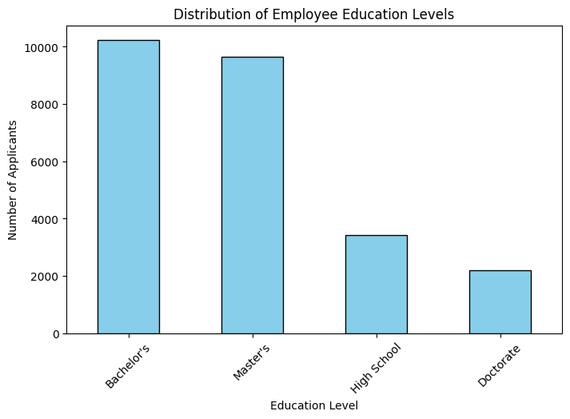

```python
# Display the count of unique education levels and their distribution
education_counts = df['education_of_employee'].value_counts()
print("Education of Employee Distribution:")
print(education_counts)

# Plot distribution of employee education levels
plt.figure(figsize=(8,5))
df['education_of_employee'].value_counts().plot(kind='bar', color='skyblue', edgecolor='black')

plt.title("Distribution of Employee Education Levels")
plt.xlabel("Education Level")
plt.ylabel("Number of Applicants")
plt.xticks(rotation=45)
plt.show()
```

Observations:

- Bachelor’s is the most common education level (~40% of applicants).
- Master’s is the second most frequent.
- High School and Doctorate appear less often.

Suggests that most visa applicants are highly educated, which may correlate with higher approval chances.

#### Observations on region of employment

```
Counts of Region of Employment:
region_of_employment
Northeast    7195
South        7017
West         6586
Midwest      4307
Island        375
Name: count, dtype: int64
```

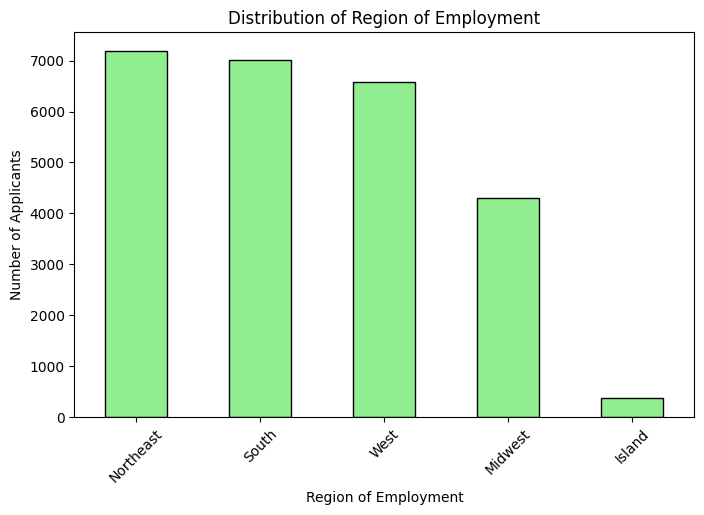

```python
# Value counts
region_counts = df['region_of_employment'].value_counts()

print("Counts of Region of Employment:")
print(region_counts)

# Plot distribution of region of employment
plt.figure(figsize=(8,5))
df['region_of_employment'].value_counts().plot(kind='bar', color='lightgreen', edgecolor='black')

plt.title("Distribution of Region of Employment")
plt.xlabel("Region of Employment")
plt.ylabel("Number of Applicants")
plt.xticks(rotation=45)
plt.show()
```

Observations:

This suggests a strong demand for foreign labor in the Northeast (possibly due to tech hubs, finance, and urban job markets).

#### Observations on job experience

```
Counts of Job Experience:
has_job_experience
Y    14802
N    10678
Name: count, dtype: int64
```

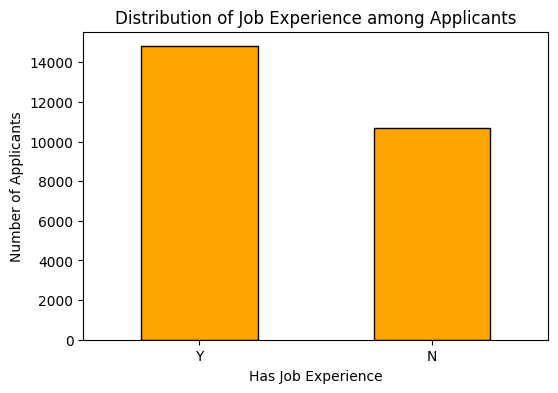

```python
# Value counts
job_exp_counts = df['has_job_experience'].value_counts()

print("Counts of Job Experience:")
print(job_exp_counts)

# Plot distribution
plt.figure(figsize=(6,4))
job_exp_counts.plot(kind='bar', color='orange', edgecolor='black')

plt.title("Distribution of Job Experience among Applicants")
plt.xlabel("Has Job Experience")
plt.ylabel("Number of Applicants")
plt.xticks(rotation=0)
plt.show()
```

Observations:

- Around 58% of applicants have job experience (Y).
- About 42% have no prior experience (N).

This shows a majority of foreign applicants bring work experience, which might positively influence approval chances.

#### Observations on case status

```
Counts of Case Status:
case_status
Certified    17018
Denied        8462
Name: count, dtype: int64
```

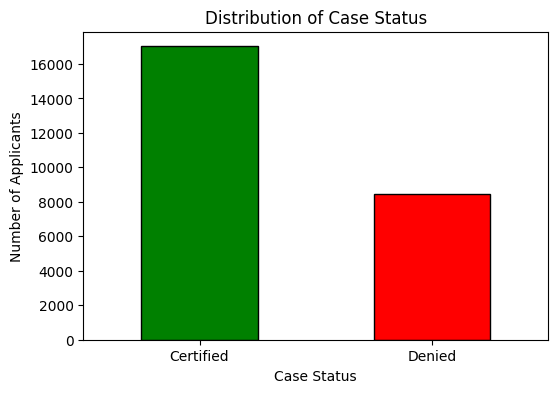

```python
# Value counts
status_counts = df['case_status'].value_counts()
print("Counts of Case Status:")
print(status_counts)

# Plot distribution
plt.figure(figsize=(6,4))
status_counts.plot(kind='bar', color=['green','red'], edgecolor='black')

plt.title("Distribution of Case Status")
plt.xlabel("Case Status")
plt.ylabel("Number of Applicants")
plt.xticks(rotation=0)
plt.show()
```

Observations:

- About 67% of cases are Certified (≈17,018 out of 25,480).
- About 33% are Denied.

This means the dataset is imbalanced, with more Certified than Denied cases.

### Bivariate Analysis

**Creating functions that will help us with further analysis.**

```python
### function to plot distributions wrt target


def distribution_plot_wrt_target(data, predictor, target):

    fig, axs = plt.subplots(2, 2, figsize=(12, 10))

    target_uniq = data[target].unique()

    axs[0, 0].set_title("Distribution of target for target=" + str(target_uniq[0]))
    sns.histplot(
        data=data[data[target] == target_uniq[0]],
        x=predictor,
        kde=True,
        ax=axs[0, 0],
        color="teal",
        stat="density",
    )

    axs[0, 1].set_title("Distribution of target for target=" + str(target_uniq[1]))
    sns.histplot(
        data=data[data[target] == target_uniq[1]],
        x=predictor,
        kde=True,
        ax=axs[0, 1],
        color="orange",
        stat="density",
    )

    axs[1, 0].set_title("Boxplot w.r.t target")
    sns.boxplot(data=data, x=target, y=predictor, ax=axs[1, 0], palette="gist_rainbow")

    axs[1, 1].set_title("Boxplot (without outliers) w.r.t target")
    sns.boxplot(
        data=data,
        x=target,
        y=predictor,
        ax=axs[1, 1],
        showfliers=False,
        palette="gist_rainbow",
    )

    plt.tight_layout()
    plt.show()
```

```python
def stacked_barplot(data, predictor, target):
    """
    Print the category counts and plot a stacked bar chart

    data: dataframe
    predictor: independent variable
    target: target variable
    """
    count = data[predictor].nunique()
    sorter = data[target].value_counts().index[-1]
    tab1 = pd.crosstab(data[predictor], data[target], margins=True).sort_values(
        by=sorter, ascending=False
    )
    print(tab1)
    print("-" * 120)
    tab = pd.crosstab(data[predictor], data[target], normalize="index").sort_values(
        by=sorter, ascending=False
    )
    tab.plot(kind="bar", stacked=True, figsize=(count + 5, 5))
    plt.legend(
        loc="lower left", frameon=False,
    )
    plt.legend(loc="upper left", bbox_to_anchor=(1, 1))
    plt.show()
```

#### Does higher education increase the chances of visa certification for well-paid jobs abroad?

```
Approval rates by education level (for well-paid jobs):
case_status            Certified     Denied
education_of_employee
Bachelor's             64.639906  35.360094
Doctorate              87.386364  12.613636
High School            34.285714  65.714286
Master's               80.534056  19.465944
```

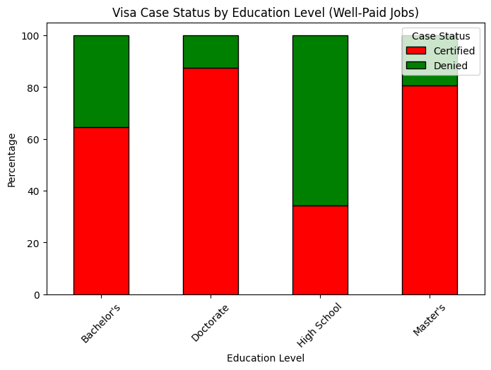

```python
# Define well-paid jobs as above the median prevailing wage
median_wage = df['prevailing_wage'].median()
well_paid = df[df['prevailing_wage'] > median_wage]

# Cross-tabulation of education vs case status (for well-paid jobs)
edu_case = pd.crosstab(well_paid['education_of_employee'], well_paid['case_status'], normalize='index') * 100

print("Approval rates by education level (for well-paid jobs):")
print(edu_case)

# Plot stacked bar chart
edu_case.plot(kind='bar', stacked=True, figsize=(8,5), color=['red','green'], edgecolor='black')

plt.title("Visa Case Status by Education Level (Well-Paid Jobs)")
plt.xlabel("Education Level")
plt.ylabel("Percentage")
plt.legend(title="Case Status")
plt.xticks(rotation=45)
plt.show()
```

Observations:

- Master’s and Doctorate applicants in high-paying jobs have higher certification rates.
- Bachelor’s applicants are moderate but still decent.
- High School applicants are more likely to be denied, even for high-wage jobs.

#### How does visa status vary across different continents?

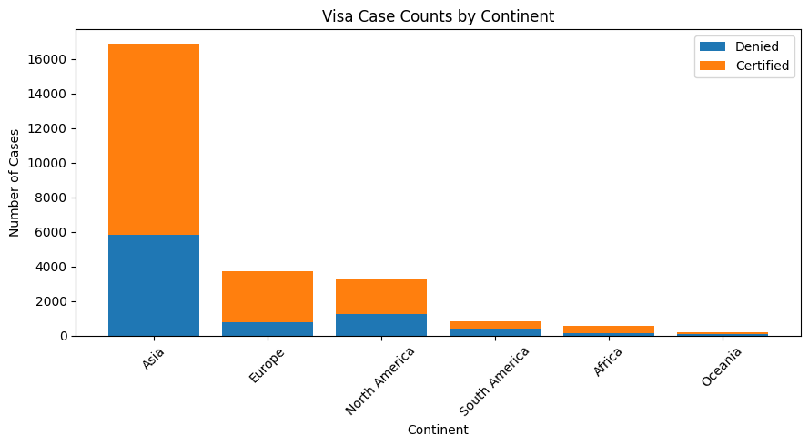

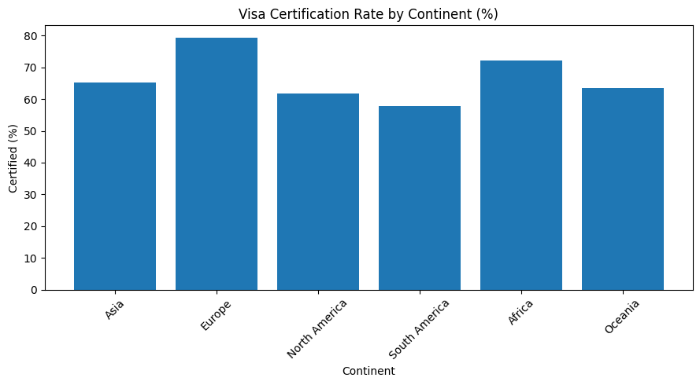

```python
# Contingency table of counts
counts = pd.crosstab(df['continent'], df['case_status'])
for col in ['Certified', 'Denied']:
    if col not in counts.columns:
        counts[col] = 0

# Order continents by total volume for readability
counts['Total'] = counts.sum(axis=1)
counts = counts.sort_values('Total', ascending=False)
counts_no_total = counts.drop(columns=['Total'])

# Certification rates (%)
rates = counts_no_total.div(counts_no_total.sum(axis=1), axis=0) * 100
cert_rate = rates['Certified']

# ----- Plot 1: Stacked bar of counts -----
plt.figure(figsize=(9, 5))
x = range(len(counts_no_total))
plt.bar(x, counts_no_total['Denied'].values, label='Denied')            # bottom layer
plt.bar(x, counts_no_total['Certified'].values,                        # stacked on top
        bottom=counts_no_total['Denied'].values, label='Certified')
plt.title("Visa Case Counts by Continent")
plt.xlabel("Continent")
plt.ylabel("Number of Cases")
plt.xticks(list(x), counts_no_total.index, rotation=45)
plt.legend()
plt.tight_layout()
plt.show()

# ----- Plot 2: Certification rate (%) -----
plt.figure(figsize=(9, 5))
plt.bar(range(len(cert_rate)), cert_rate.values)
plt.title("Visa Certification Rate by Continent (%)")
plt.xlabel("Continent")
plt.ylabel("Certified (%)")
plt.xticks(range(len(cert_rate)), cert_rate.index, rotation=45)
plt.tight_layout()
plt.show()
```

#### Does having prior work experience influence the chances of visa certification for career opportunities abroad?

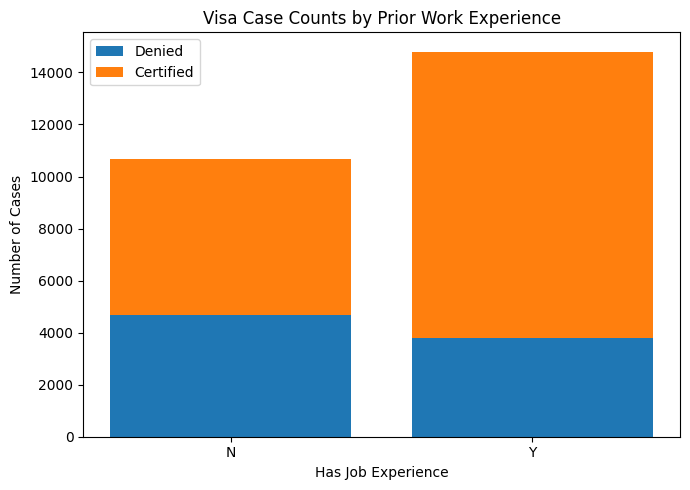

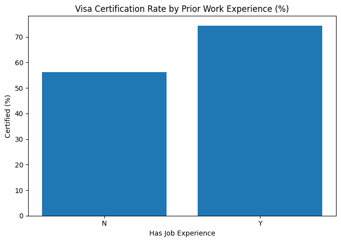

```python
# Normalize experience flags
df['has_job_experience'] = df['has_job_experience'].astype(str).str.strip().str.upper()

# Counts by experience vs status
counts = pd.crosstab(df['has_job_experience'], df['case_status'])
for col in ['Certified', 'Denied']:
    if col not in counts.columns:
        counts[col] = 0

# Certification rate (% Certified)
rates = counts.div(counts.sum(axis=1), axis=0) * 100
cert_rate = rates['Certified']

# --- Plot A: stacked counts ---
plt.figure(figsize=(7, 5))
x = range(len(counts))
plt.bar(x, counts['Denied'].values, label='Denied')
plt.bar(x, counts['Certified'].values, bottom=counts['Denied'].values, label='Certified')
plt.title("Visa Case Counts by Prior Work Experience")
plt.xlabel("Has Job Experience")
plt.ylabel("Number of Cases")
plt.xticks(list(x), counts.index, rotation=0)
plt.legend()
plt.tight_layout()
plt.show()

# --- Plot B: certification rate ---
plt.figure(figsize=(7, 5))
plt.bar(range(len(cert_rate)), cert_rate.values)
plt.title("Visa Certification Rate by Prior Work Experience (%)")
plt.xlabel("Has Job Experience")
plt.ylabel("Certified (%)")
plt.xticks(range(len(cert_rate)), cert_rate.index, rotation=0)
plt.tight_layout()
plt.show()
```

Observations:

#### Is the prevailing wage consistent across all regions of the US?

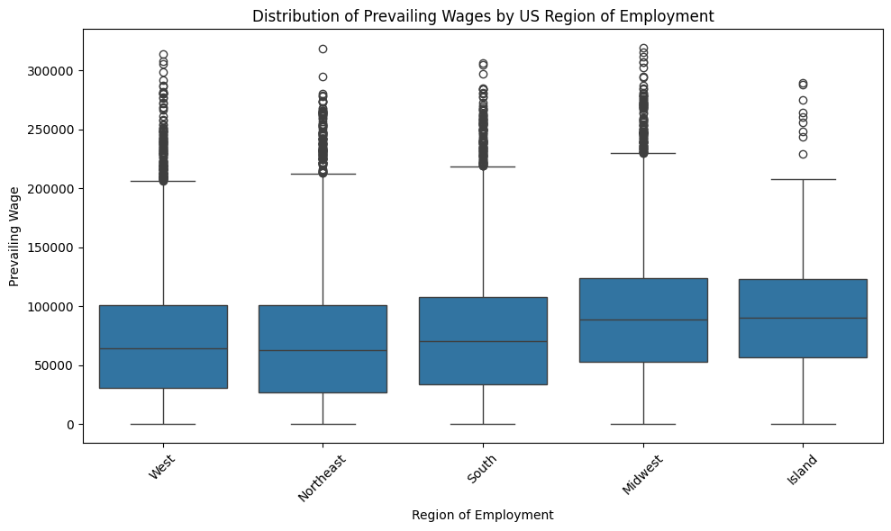

```python
# Boxplot: prevailing wage by region
plt.figure(figsize=(10,6))
sns.boxplot(x="region_of_employment", y="prevailing_wage", data=df)
plt.title("Distribution of Prevailing Wages by US Region of Employment")
plt.xlabel("Region of Employment")
plt.ylabel("Prevailing Wage")
plt.xticks(rotation=45)
plt.tight_layout()
plt.show()
```

#### Does visa status vary with changes in the prevailing wage set to protect both local talent and foreign workers?

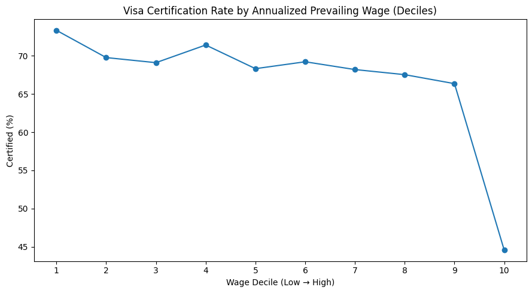

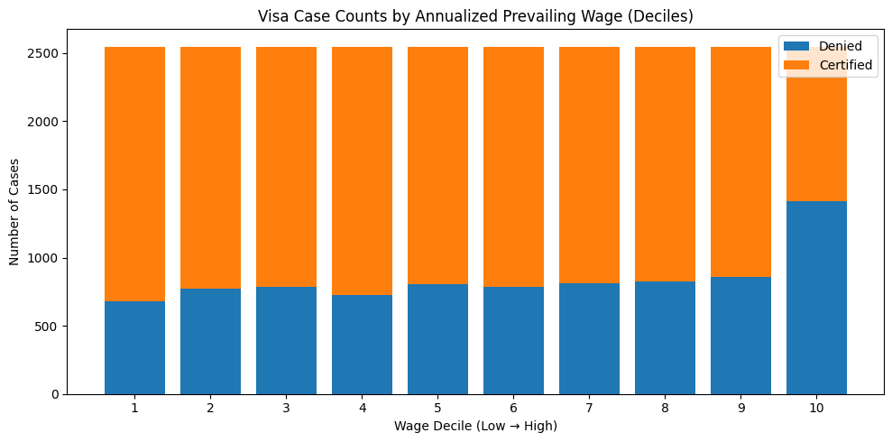

```python
# ---- 1) Annualize prevailing wage by unit ----
unit = df['unit_of_wage'].astype(str).str.strip().str.title()
mult = (
    unit.replace({
        'Hourly': 'Hour', 'Hour': 'Hour',
        'Weekly': 'Week', 'Week': 'Week',
        'Monthly': 'Month', 'Month': 'Month',
        'Yearly': 'Year', 'Year': 'Year'
    })
    .map({'Hour': 2080, 'Week': 52, 'Month': 12, 'Year': 1})
)
df['wage_annual'] = df['prevailing_wage'] * mult
df = df.dropna(subset=['wage_annual']).copy()
df = df[df['wage_annual'] > 0].copy()  # remove nonpositive

# ---- 2) Wage deciles ----
df['wage_decile'] = pd.qcut(df['wage_annual'], 10, duplicates='drop')

# Target flag
df['is_certified'] = (df['case_status'].astype(str).str.strip().str.title() == 'Certified').astype(int)

# Aggregate per decile
agg = df.groupby('wage_decile').agg(
    total_cases=('is_certified', 'size'),
    certified_count=('is_certified', 'sum'),
    certified_rate_pct=('is_certified', lambda s: 100 * s.mean() if len(s) else np.nan),
    min_wage=('wage_annual', 'min'),
    max_wage=('wage_annual', 'max'),
    median_wage=('wage_annual', 'median')
).reset_index()

# Order by wage
agg = agg.sort_values('median_wage').reset_index(drop=True)

# ---- Plot 1: Certification rate by decile ----
plt.figure(figsize=(9,5))
plt.plot(range(1, len(agg)+1), agg['certified_rate_pct'], marker='o')
plt.title("Visa Certification Rate by Annualized Prevailing Wage (Deciles)")
plt.xlabel("Wage Decile (Low → High)")
plt.ylabel("Certified (%)")
plt.xticks(range(1, len(agg)+1))
plt.tight_layout()
plt.show()

# ---- Plot 2: Stacked counts by decile ----
denied_counts = agg['total_cases'] - agg['certified_count']
x = np.arange(len(agg)) + 1

plt.figure(figsize=(10,5))
plt.bar(x, denied_counts, label='Denied')
plt.bar(x, agg['certified_count'], bottom=denied_counts, label='Certified')
plt.title("Visa Case Counts by Annualized Prevailing Wage (Deciles)")
plt.xlabel("Wage Decile (Low → High)")
plt.ylabel("Number of Cases")
plt.xticks(x)
plt.legend()
plt.tight_layout()
plt.show()
```

Observations:

- Certification rates vary with wage level.
- After annualizing and binning, mid-to-high wage deciles generally maintain ~68–72% certification, with a drop in the top decile, suggesting stricter scrutiny or heterogeneous occupations at the very high end.
- Stacked counts confirm more denials in the highest wage decile relative to others.

#### Does the unit of prevailing wage (Hourly, Weekly, etc.) have any impact on the likelihood of visa application certification?

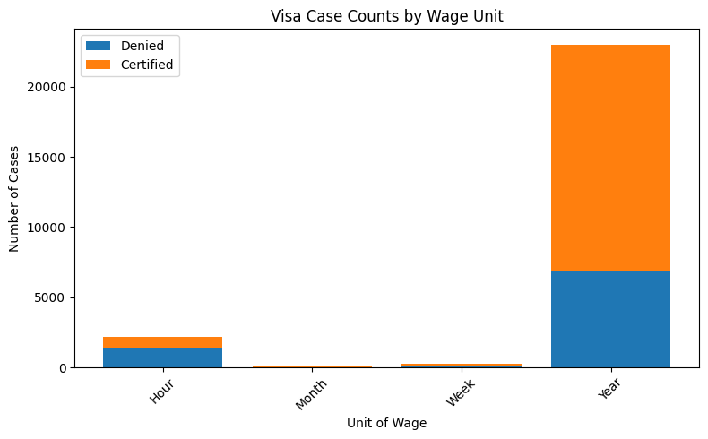

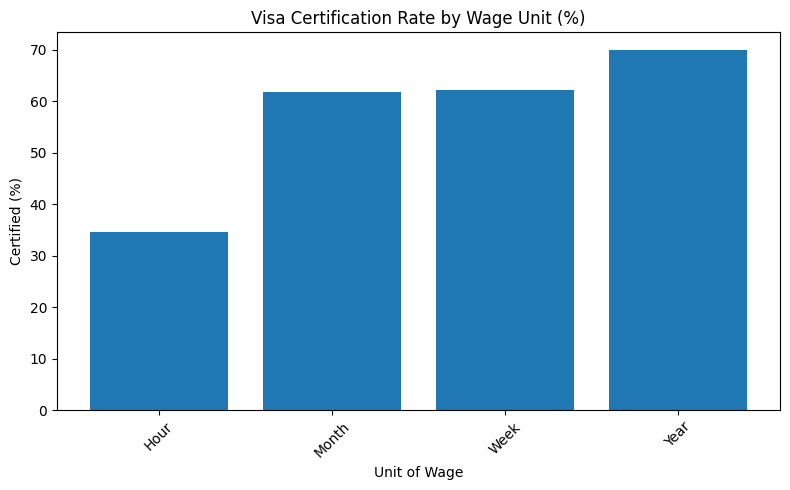

```python
# Normalize unit text
df['unit_of_wage'] = df['unit_of_wage'].astype(str).str.strip().str.title()

# Counts by unit vs status
counts = pd.crosstab(df['unit_of_wage'], df['case_status'])
for col in ['Certified','Denied']:
    if col not in counts.columns:
        counts[col] = 0

# Certification rates (%)
rates = counts.div(counts.sum(axis=1), axis=0) * 100
cert_rate = rates['Certified']

# --- Plot 1: Stacked counts ---
plt.figure(figsize=(8,5))
x = range(len(counts))
plt.bar(x, counts['Denied'].values, label='Denied')
plt.bar(x, counts['Certified'].values, bottom=counts['Denied'].values, label='Certified')
plt.title("Visa Case Counts by Wage Unit")
plt.xlabel("Unit of Wage")
plt.ylabel("Number of Cases")
plt.xticks(list(x), counts.index, rotation=45)
plt.legend()
plt.tight_layout()
plt.show()

# --- Plot 2: Certification rate ---
plt.figure(figsize=(8,5))
plt.bar(range(len(cert_rate)), cert_rate.values)
plt.title("Visa Certification Rate by Wage Unit (%)")
plt.xlabel("Unit of Wage")
plt.ylabel("Certified (%)")
plt.xticks(range(len(cert_rate)), cert_rate.index, rotation=45)
plt.tight_layout()
plt.show()
```

Observations:

## Data Pre-processing

### Outlier Check

```python
# 1) Select numeric columns
num_cols = df.select_dtypes(include=['int64','float64']).columns

# 2) Compute summary stats + IQR bounds
summary_stats = df[num_cols].describe().T
summary_stats['IQR'] = summary_stats['75%'] - summary_stats['25%']
summary_stats['Lower_Bound'] = summary_stats['25%'] - 1.5 * summary_stats['IQR']
summary_stats['Upper_Bound'] = summary_stats['75%'] + 1.5 * summary_stats['IQR']

# 3) Count outliers for each numeric feature
outlier_counts = {}
for col in num_cols:
    lb, ub = summary_stats.loc[col, ['Lower_Bound','Upper_Bound']]
    outlier_counts[col] = ((df[col] < lb) | (df[col] > ub)).sum()

summary_stats['Outlier_Count'] = pd.Series(outlier_counts)

# 4) Print summary table
print("\n Outlier Summary (IQR Method):\n")
print(summary_stats[['mean','std','min','25%','50%','75%','max','Lower_Bound','Upper_Bound','Outlier_Count']])
```

```
 Outlier Summary (IQR Method):

                          mean            std        min        25%       50%  \
no_of_employees    5667.089207   22877.917453    11.0000   1022.000   2109.00
yr_of_estab        1979.409929      42.366929  1800.0000   1976.000   1997.00
prevailing_wage   74455.814592   52815.942327     2.1367  34015.480  70308.21
wage_annual      197391.155259  578591.666314   100.0000  47107.965  82839.46
is_certified          0.667896       0.470977     0.0000      0.000      1.00

                         75%          max  Lower_Bound   Upper_Bound  \
no_of_employees    3504.0000    602069.00  -2701.00000    7227.00000
yr_of_estab        2005.0000      2016.00   1932.50000    2048.50000
prevailing_wage  107735.5125    319210.27 -76564.56875  218315.56125
wage_annual      124825.0350  14569149.40 -69467.64000  241400.64000
is_certified          1.0000         1.00     -1.50000       2.50000

                 Outlier_Count
no_of_employees           1556
yr_of_estab               3260
prevailing_wage            427
wage_annual               2387
is_certified                 0
```

Observations:

- no_of_employees shows extreme outliers (very large company sizes).
- yr_of_estab has values as early as the 1800s, likely outliers or data errors.
- prevailing_wage has very high wage values compared to the median — these are flagged as outliers.

### Data Preparation for modeling

```python
# Basic cleaning
df['no_of_employees'] = df['no_of_employees'].apply(lambda x: x if x >= 0 else None)
df = df.dropna(subset=['no_of_employees', 'prevailing_wage'])
df = df[(df['yr_of_estab'] >= 1900) & (df['yr_of_estab'] <= 2025)].copy()

# Normalize categoricals
cat_cols = [
  'continent','education_of_employee','has_job_experience',
  'requires_job_training','region_of_employment','unit_of_wage',
  'full_time_position'
]
for c in cat_cols:
  df[c] = df[c].astype(str).str.strip().str.title()

# Target
df['case_status'] = df['case_status'].astype(str).str.strip().str.title()
df['case_status_bin'] = df['case_status'].map({'Certified':1,'Denied':0}).astype(int)

# One-hot encoding
df_model = df.drop(columns=['case_id','case_status'])
df_model = pd.get_dummies(df_model, columns=cat_cols, drop_first=True)

# Build X (leakage-free) and y
cols_to_drop = [c for c in ['case_status_bin','is_certified','wage_decile'] if c in df_model.columns]
X = df_model.drop(columns=cols_to_drop)
y = df_model['case_status_bin']

# Train/test split
X_train, X_test, y_train, y_test = train_test_split(
        X, y, test_size=0.20, random_state=1, stratify=y
)
print("\n Data Preparation Done! \n")
```

```
 Data Preparation Done!
```

## Model Building

### Model Evaluation Criterion

First, let's create functions to calculate different metrics and confusion matrix so that we don't have to use the same code repeatedly for each model.

- The `model_performance_classification_sklearn` function will be used to check the model performance of models.
- The `confusion_matrix_sklearn` function will be used to plot the confusion matrix.

```python
# defining a function to compute different metrics to check performance of a classification model built using sklearn


def model_performance_classification_sklearn(model, predictors, target):
    """
    Function to compute different metrics to check classification model performance

    model: classifier
    predictors: independent variables
    target: dependent variable
    """

    # predicting using the independent variables
    pred = model.predict(predictors)

    acc = accuracy_score(target, pred)  # to compute Accuracy
    recall = recall_score(target, pred)  # to compute Recall
    precision = precision_score(target, pred)  # to compute Precision
    f1 = f1_score(target, pred)  # to compute F1-score

    # creating a dataframe of metrics
    df_perf = pd.DataFrame(
        {"Accuracy": acc, "Recall": recall, "Precision": precision, "F1": f1,},
        index=[0],
    )

    return df_perf
```

```python
def confusion_matrix_sklearn(model, predictors, target):
    """
    To plot the confusion_matrix with percentages

    model: classifier
    predictors: independent variables
    target: dependent variable
    """
    y_pred = model.predict(predictors)
    cm = confusion_matrix(target, y_pred)
    labels = np.asarray(
        [
            ["{0:0.0f}".format(item) + "\n{0:.2%}".format(item / cm.flatten().sum())]
            for item in cm.flatten()
        ]
    ).reshape(2, 2)

    plt.figure(figsize=(6, 4))
    sns.heatmap(cm, annot=labels, fmt="")
    plt.ylabel("True label")
    plt.xlabel("Predicted label")
```

#### Defining scorer to be used for cross-validation and hyperparameter tuning

Primary Metric Choice: Average Precision (PR AUC):

- The dataset is imbalanced (~67% Certified vs ~33% Denied).
- Standard accuracy would be misleading (a “certify everyone” model would look good).
- ROC-AUC is often used, but with imbalance, it can overestimate performance because it treats both classes equally across thresholds.
- Average Precision (AP), which summarizes the Precision–Recall curve, directly reflects the model’s ability to rank Certified cases high while avoiding false positives.
- This aligns with the business goal: shortlist applicants who are more likely to be Certified.

Define Scorer for Cross-Validation

```python
## --- Primary metric scorer ---
ap_scorer = "average_precision"

## --- CV strategy ---
kfold = StratifiedKFold(n_splits=5, shuffle=True, random_state=1)
```

**We are now done with pre-processing and evaluation criterion, so let's start building the model.**

### Model building with Original data

```python
# ----- Five models (100 estimators where applicable) -----
models = [
    ("DecisionTree",
     DecisionTreeClassifier(
         random_state=1, class_weight="balanced",
         max_depth=12, min_samples_leaf=2
     )),
    ("RandomForest",
     RandomForestClassifier(
         random_state=1, n_estimators=100, n_jobs=-1,
         class_weight="balanced_subsample",
         max_depth=16, min_samples_leaf=2
     )),
    ("GradientBoosting",
     GradientBoostingClassifier(
         random_state=1, n_estimators=100,
         learning_rate=0.08, max_depth=3, subsample=0.9
     )),
    ("AdaBoost",
     AdaBoostClassifier(
         random_state=1, n_estimators=100, learning_rate=0.08
     )),
    ("BaggingDT",
        BaggingClassifier(
            estimator=DecisionTreeClassifier(
                random_state=1, class_weight="balanced",
                max_depth=12, min_samples_leaf=2
            ),
            random_state=1, n_estimators=100, n_jobs=-1,
            bootstrap=True, max_samples=1.0, max_features=1.0
    ))
]

# ----- Train/evaluate (CV AP + Test AP/F1) -----
rows = []
print("\nCross-Validation (AP) on training folds:\n")
for name, model in models:
    # CV AP
    cv_scores = cross_val_score(model, X_train, y_train,
                                scoring=ap_scorer, cv=kfold, n_jobs=-1,
                                error_score='raise')
    print(f"{name}: mean={cv_scores.mean():.4f}  std={cv_scores.std():.4f}")

    # Fit on full train
    model.fit(X_train, y_train)

    # Probabilities for AP (valid PR AUC)
    y_score = model.predict_proba(X_test)[:, 1]

    ap_test = average_precision_score(y_test, y_score)

    # F1 at a simple 0.5 threshold
    y_pred = (y_score >= 0.5).astype(int)
    f1 = f1_score(y_test, y_pred)

    tn, fp, fn, tp = confusion_matrix(y_test, y_pred).ravel()
    rows.append({
        "Model": name,
        "CV_AP_mean": round(float(cv_scores.mean()), 4),
        "CV_AP_std": round(float(cv_scores.std()), 4),
        "Test_AP": round(float(ap_test), 4),
        "Test_F1@0.5": round(float(f1), 4),
        "TP": int(tp), "FP": int(fp), "TN": int(tn), "FN": int(fn)
    })

# ----- Comparison table -----
results_df = pd.DataFrame(rows).sort_values("Test_AP", ascending=False).reset_index(drop=True)
print("\n=== Model Comparison (100 estimators where applicable) ===")
print(results_df.to_string(index=False))
```

```
Cross-Validation (AP) on training folds:

DecisionTree: mean=0.8057  std=0.0103
RandomForest: mean=0.8701  std=0.0050
GradientBoosting: mean=0.8697  std=0.0060
AdaBoost: mean=0.8347  std=0.0092
BaggingDT: mean=0.8697  std=0.0060

=== Model Comparison (100 estimators where applicable) ===
           Model  CV_AP_mean  CV_AP_std  Test_AP  Test_F1@0.5   TP   FP  TN  FN
    RandomForest      0.8701     0.0050   0.8770       0.7995 2475  592 959 649
GradientBoosting      0.8697     0.0060   0.8754       0.8198 2714  783 768 410
       BaggingDT      0.8697     0.0060   0.8737       0.7922 2431  582 969 693
        AdaBoost      0.8347     0.0092   0.8359       0.8109 2996 1269 282 128
    DecisionTree      0.8057     0.0103   0.8087       0.7613 2263  558 993 861
```

### Model Building with Oversampled data

```python
# Oversample ONLY the training set (no leakage)
print("Class balance before oversampling (y_train):", pd.Series(y_train).value_counts().to_dict())
smote = SMOTE(random_state=1, k_neighbors=5)
X_train_os, y_train_os = smote.fit_resample(X_train, y_train)
print("Class balance after oversampling (y_train_os):", pd.Series(y_train_os).value_counts().to_dict())

# Five models (100 estimators where applicable)
models = [
    ("DecisionTree",
     DecisionTreeClassifier(
         random_state=1, class_weight="balanced",
         max_depth=12, min_samples_leaf=2
     )),
    ("RandomForest",
     RandomForestClassifier(
         random_state=1, n_estimators=100, n_jobs=-1,
         class_weight="balanced_subsample",
         max_depth=16, min_samples_leaf=2
     )),
    ("GradientBoosting",
     GradientBoostingClassifier(
         random_state=1, n_estimators=100,
         learning_rate=0.08, max_depth=3, subsample=0.9
     )),
    ("AdaBoost",
     AdaBoostClassifier(
         random_state=1, n_estimators=100, learning_rate=0.08
     )),
    ("BaggingDT",
        BaggingClassifier(
            estimator=DecisionTreeClassifier(
                random_state=1, class_weight="balanced",
                max_depth=12, min_samples_leaf=2
            ),
            random_state=1, n_estimators=100, n_jobs=-1,
            bootstrap=True, max_samples=1.0, max_features=1.0
    ))
]

# Train/evaluate using oversampled train, test on original test
rows = []
print("\nCross-Validation (AP) on OVERSAMPLED training folds:\n")
for name, model in models:
    # CV on oversampled train (simple approach)
    cv_scores = cross_val_score(model, X_train_os, y_train_os,
                                scoring=ap_scorer, cv=kfold, n_jobs=-1, error_score='raise')
    print(f"{name}: mean={cv_scores.mean():.4f}  std={cv_scores.std():.4f}")

    # Fit on oversampled train
    model.fit(X_train_os, y_train_os)

    # Probabilities for AP on untouched test set
    y_score = model.predict_proba(X_test)[:, 1]
    ap_test = average_precision_score(y_test, y_score)

    # F1 at 0.5 threshold
    y_pred = (y_score >= 0.5).astype(int)
    f1 = f1_score(y_test, y_pred)

    tn, fp, fn, tp = confusion_matrix(y_test, y_pred).ravel()
    rows.append({
        "Model": name,
        "CV_AP_mean (OS)": round(float(cv_scores.mean()), 4),
        "CV_AP_std (OS)": round(float(cv_scores.std()), 4),
        "Test_AP": round(float(ap_test), 4),
        "Test_F1@0.5": round(float(f1), 4),
        "TP": int(tp), "FP": int(fp), "TN": int(tn), "FN": int(fn)
    })

# Comparison table
results_os = pd.DataFrame(rows).sort_values("Test_AP", ascending=False).reset_index(drop=True)
print("\n=== Model Comparison with SMOTE (train oversampled) ===")
print(results_os.to_string(index=False))
```

```
Class balance before oversampling (y_train): {1: 12492, 0: 6205}
Class balance after oversampling (y_train_os): {1: 12492, 0: 12492}

Cross-Validation (AP) on OVERSAMPLED training folds:

DecisionTree: mean=0.7775  std=0.0115
RandomForest: mean=0.8592  std=0.0064
GradientBoosting: mean=0.8435  std=0.0062
AdaBoost: mean=0.7274  std=0.0124
BaggingDT: mean=0.8465  std=0.0056

=== Model Comparison with SMOTE (train oversampled) ===
           Model  CV_AP_mean (OS)  CV_AP_std (OS)  Test_AP  Test_F1@0.5   TP   FP  TN  FN
    RandomForest           0.8592          0.0064   0.8721       0.8076 2622  747 804 502
       BaggingDT           0.8465          0.0056   0.8717       0.8101 2626  733 818 498
GradientBoosting           0.8435          0.0062   0.8651       0.8124 2644  741 810 480
    DecisionTree           0.7775          0.0115   0.8132       0.8017 2602  765 786 522
        AdaBoost           0.7274          0.0124   0.7770       0.8126 2866 1064 487 258
```

### Model Building with Undersampled data

```python
# Undersample ONLY the training set (no leakage)
print("Class balance before undersampling (y_train):", pd.Series(y_train).value_counts().to_dict())
rus = RandomUnderSampler(random_state=1, sampling_strategy=1.0)  # 1.0 => balance classes
X_train_us, y_train_us = rus.fit_resample(X_train, y_train)
print("Class balance after undersampling (y_train_us):", pd.Series(y_train_us).value_counts().to_dict())

# Five models (100 estimators where applicable)
models = [
    ("DecisionTree",
     DecisionTreeClassifier(
         random_state=1, class_weight="balanced",
         max_depth=12, min_samples_leaf=2
     )),
    ("RandomForest",
     RandomForestClassifier(
         random_state=1, n_estimators=100, n_jobs=-1,
         class_weight="balanced_subsample",
         max_depth=16, min_samples_leaf=2
     )),
    ("GradientBoosting",
     GradientBoostingClassifier(
         random_state=1, n_estimators=100,
         learning_rate=0.08, max_depth=3, subsample=0.9
     )),
    ("AdaBoost",
     AdaBoostClassifier(
         random_state=1, n_estimators=100, learning_rate=0.08
     )),
    ("BaggingDT",
        BaggingClassifier(
            estimator=DecisionTreeClassifier(
                random_state=1, class_weight="balanced",
                max_depth=12, min_samples_leaf=2
            ),
            random_state=1, n_estimators=100, n_jobs=-1,
            bootstrap=True, max_samples=1.0, max_features=1.0
    ))
]

# Train/evaluate using UNDERSAMPLED train, test on original test
rows = []
print("\nCross-Validation (AP) on UNDERSAMPLED training folds:\n")
for name, model in models:
    # CV on undersampled train (simple approach)
    cv_scores = cross_val_score(model, X_train_us, y_train_us,
                                scoring=ap_scorer, cv=kfold, n_jobs=-1, error_score='raise')
    print(f"{name}: mean={cv_scores.mean():.4f}  std={cv_scores.std():.4f}")

    # Fit on undersampled train
    model.fit(X_train_us, y_train_us)

    # Probabilities for AP on untouched test set
    y_score = model.predict_proba(X_test)[:, 1]
    ap_test = average_precision_score(y_test, y_score)

    # F1 at 0.5 threshold
    y_pred = (y_score >= 0.5).astype(int)
    f1 = f1_score(y_test, y_pred)

    tn, fp, fn, tp = confusion_matrix(y_test, y_pred).ravel()
    rows.append({
        "Model": name,
        "CV_AP_mean (US)": round(float(cv_scores.mean()), 4),
        "CV_AP_std (US)": round(float(cv_scores.std()), 4),
        "Test_AP": round(float(ap_test), 4),
        "Test_F1@0.5": round(float(f1), 4),
        "TP": int(tp), "FP": int(fp), "TN": int(tn), "FN": int(fn)
    })

# Comparison table
results_us = pd.DataFrame(rows).sort_values("Test_AP", ascending=False).reset_index(drop=True)
print("\n=== Model Comparison with RandomUnderSampler (train undersampled) ===")
print(results_us.to_string(index=False))
```

```
Class balance before undersampling (y_train): {1: 12492, 0: 6205}
Class balance after undersampling (y_train_us): {0: 6205, 1: 6205}

Cross-Validation (AP) on UNDERSAMPLED training folds:

DecisionTree: mean=0.6796  std=0.0098
RandomForest: mean=0.7824  std=0.0111
GradientBoosting: mean=0.7810  std=0.0105
AdaBoost: mean=0.7164  std=0.0217
BaggingDT: mean=0.7809  std=0.0105

=== Model Comparison with RandomUnderSampler (train undersampled) ===
           Model  CV_AP_mean (US)  CV_AP_std (US)  Test_AP  Test_F1@0.5   TP  FP   TN  FN
GradientBoosting           0.7810          0.0105   0.8766       0.7705 2264 489 1062 860
    RandomForest           0.7824          0.0111   0.8759       0.7676 2246 482 1069 878
       BaggingDT           0.7809          0.0105   0.8746       0.7702 2269 499 1052 855
        AdaBoost           0.7164          0.0217   0.8354       0.7835 2437 660  891 687
    DecisionTree           0.6796          0.0098   0.8140       0.7441 2142 491 1060 982
```

## Hyperparameter Tuning

**Best practices for hyperparameter tuning in AdaBoost:**

`n_estimators`:

- Start with a specific number (50 is used in general) and increase in steps: 50, 75, 85, 100
- Use fewer estimators (e.g., 50 to 100) if using complex base learners (like deeper decision trees)
- Use more estimators (e.g., 100 to 150) when learning rate is low (e.g., 0.1 or lower)
- Avoid very high values unless performance keeps improving on validation

`learning_rate`:

- Common values to try: 1.0, 0.5, 0.1, 0.01
- Use 1.0 for faster training, suitable for fewer estimators
- Use 0.1 or 0.01 when using more estimators to improve generalization
- Avoid very small values (< 0.01) unless you plan to use many estimators (e.g., >500) and have sufficient data

**Best practices for hyperparameter tuning in Random Forest:**

`n_estimators`:

- Start with a specific number (50 is used in general) and increase in steps: 50, 75, 100, 125
- Higher values generally improve performance but increase training time
- Use 100-150 for large datasets or when variance is high

`min_samples_leaf`:

- Try values like: 1, 2, 4, 5, 10
- Higher values reduce model complexity and help prevent overfitting
- Use 1–2 for low-bias models, higher (like 5 or 10) for more regularized models
- Works well in noisy datasets to smooth predictions

`max_features`:

- Try values: `"sqrt"` (default for classification), `"log2"`, `None`, or float values (e.g., `0.3`, `0.5`)
- `"sqrt"` balances between diversity and performance for classification tasks
- Lower values (e.g., `0.3`) increase tree diversity, reducing overfitting
- Higher values (closer to `1.0`) may capture more interactions but risk overfitting

`max_samples` (for bootstrap sampling):

- Try float values between `0.5` to `1.0` or fixed integers
- Use `0.6–0.9` to introduce randomness and reduce overfitting
- Smaller values increase diversity between trees, improving generalization

**Best practices for hyperparameter tuning in Gradient Boosting:**

`n_estimators`:

- Start with 100 (default) and increase: 100, 200, 300, 500
- Typically, higher values lead to better performance, but they also increase training time
- Use 200–500 for larger datasets or complex problems
- Monitor validation performance to avoid overfitting, as too many estimators can degrade generalization

`learning_rate`:

- Common values to try: 0.1, 0.05, 0.01, 0.005
- Use lower values (e.g., 0.01 or 0.005) if you are using many estimators (e.g., > 200)
- Higher learning rates (e.g., 0.1) can be used with fewer estimators for faster convergence
- Always balance the learning rate with `n_estimators` to prevent overfitting or underfitting

`subsample`:

- Common values: 0.7, 0.8, 0.9, 1.0
- Use a value between `0.7` and `0.9` for improved generalization by introducing randomness
- `1.0` uses the full dataset for each boosting round, potentially leading to overfitting
- Reducing `subsample` can help reduce overfitting, especially in smaller datasets

`max_features`:

- Common values: `"sqrt"`, `"log2"`, or float (e.g., `0.3`, `0.5`)
- `"sqrt"` (default) works well for classification tasks
- Lower values (e.g., `0.3`) help reduce overfitting by limiting the number of features considered at each split

**Best practices for hyperparameter tuning in XGBoost:**

`n_estimators`:

- Start with 50 and increase in steps: 50,75,100,125.
- Use more estimators (e.g., 150-250) when using lower learning rates
- Monitor validation performance
- High values improve learning but increase training time

`subsample`:

- Common values: 0.5, 0.7, 0.8, 1.0
- Use `0.7–0.9` to introduce randomness and reduce overfitting
- `1.0` uses the full dataset in each boosting round; may overfit on small datasets
- Values < 0.5 are rarely useful unless dataset is very large

`gamma`:

- Try values: 0 (default), 1, 3, 5, 8
- Controls minimum loss reduction needed for a split
- Higher values make the algorithm more conservative (i.e., fewer splits)
- Use values > 0 to regularize and reduce overfitting, especially on noisy data

`colsample_bytree`:

- Try values: 0.3, 0.5, 0.7, 1.0
- Fraction of features sampled per tree
- Lower values (e.g., 0.3 or 0.5) increase randomness and improve generalization
- Use `1.0` when you want all features considered for every tree

`colsample_bylevel`:

- Try values: 0.3, 0.5, 0.7, 1.0
- Fraction of features sampled at each tree level (i.e., per split depth)
- Lower values help in regularization and reducing overfitting
- Often used in combination with `colsample_bytree` for fine control over feature sampling

-> Consolidated Ranking Across All Strategies

Why not AdaBoost or DecisionTree?

- AdaBoost: sometimes gives decent F1, but Test AP is much lower (0.774–0.84 range). Doesn’t compete with the top 3.
- DecisionTree: weakest by far; only useful as a baseline benchmark.

Final Top 3 Models for Hyperparameter Tuning:

```python
# Search space
rf_param_dist = {
    "n_estimators":    [75, 100, 125],
    "min_samples_leaf":[1, 2, 4, 5],
    "max_features":    ["sqrt", "log2", 0.5],
    "max_samples":     [0.7, 0.9, 1.0],
}

rf = RandomForestClassifier(random_state=1, n_jobs=-1, bootstrap=True,
                            class_weight="balanced_subsample")

cv = StratifiedKFold(n_splits=3, shuffle=True, random_state=1)
rs_rf = RandomizedSearchCV(
    estimator=rf,
    param_distributions=rf_param_dist,
    n_iter=12,
    scoring="average_precision",
    cv=cv,
    n_jobs=-1,
    random_state=1,
    refit=True,
    verbose=1
)
rs_rf.fit(X_train, y_train)
print("\n[RF] Best params:", rs_rf.best_params_)
print("[RF] Best CV AP :", f"{rs_rf.best_score_:.4f}")

# Test evaluation
best_rf = rs_rf.best_estimator_
rf_score = best_rf.predict_proba(X_test)[:, 1]
rf_ap = average_precision_score(y_test, rf_score)
rf_f1 = f1_score(y_test, (rf_score >= 0.5).astype(int))
tn, fp, fn, tp = confusion_matrix(y_test, (rf_score >= 0.5).astype(int)).ravel()
print("[RF] Test AP    :", f"{rf_ap:.4f}")
print("[RF] Test F1@0.5:", f"{rf_f1:.4f}")
print(f"[RF] Confusion  : TP={tp}  FP={fp}  TN={tn}  FN={fn}")
```

```
Fitting 3 folds for each of 12 candidates, totalling 36 fits

[RF] Best params: {'n_estimators': 100, 'min_samples_leaf': 5, 'max_samples': 0.9, 'max_features': 'log2'}
[RF] Best CV AP : 0.8708
[RF] Test AP    : 0.8771
[RF] Test F1@0.5: 0.7916
[RF] Confusion  : TP=2426  FP=579  TN=972  FN=698
```

```python
gb_param_dist = {
    "n_estimators":  [100, 200, 300],
    "learning_rate": [0.1, 0.05, 0.01],
    "subsample":     [0.7, 0.85, 1.0],
    "max_features":  ["sqrt", 0.5],
}

gb = GradientBoostingClassifier(random_state=1)

cv = StratifiedKFold(n_splits=3, shuffle=True, random_state=1)
rs_gb = RandomizedSearchCV(
    estimator=gb,
    param_distributions=gb_param_dist,
    n_iter=12,
    scoring="average_precision",
    cv=cv,
    n_jobs=-1,
    random_state=1,
    refit=True,
    verbose=1
)
rs_gb.fit(X_train, y_train)
print("\n[GB] Best params:", rs_gb.best_params_)
print("[GB] Best CV AP :", f"{rs_gb.best_score_:.4f}")

best_gb = rs_gb.best_estimator_
gb_score = best_gb.predict_proba(X_test)[:, 1]
gb_ap = average_precision_score(y_test, gb_score)
gb_f1 = f1_score(y_test, (gb_score >= 0.5).astype(int))
tn, fp, fn, tp = confusion_matrix(y_test, (gb_score >= 0.5).astype(int)).ravel()
print("[GB] Test AP    :", f"{gb_ap:.4f}")
print("[GB] Test F1@0.5:", f"{gb_f1:.4f}")
print(f"[GB] Confusion  : TP={tp}  FP={fp}  TN={tn}  FN={fn}")
```

```
Fitting 3 folds for each of 12 candidates, totalling 36 fits

[GB] Best params: {'subsample': 0.7, 'n_estimators': 200, 'max_features': 0.5, 'learning_rate': 0.05}
[GB] Best CV AP : 0.8695
[GB] Test AP    : 0.8753
[GB] Test F1@0.5: 0.8186
[GB] Confusion  : TP=2717  FP=797  TN=754  FN=407
```

```python
bag_base = DecisionTreeClassifier(
    random_state=1, class_weight="balanced", max_depth=12, min_samples_leaf=2
)

bag = BaggingClassifier(
    estimator=bag_base,
    random_state=1, n_estimators=100, n_jobs=-1,
    bootstrap=True
)

bag_param_dist = {
    "n_estimators":              [75, 100, 125],
    "max_samples":               [0.6, 0.8, 1.0],
    "max_features":              [0.5, 1.0],
    "estimator__max_depth":      [6, 10, 16],
    "estimator__min_samples_leaf":[1, 2, 4],
}

cv = StratifiedKFold(n_splits=3, shuffle=True, random_state=1)
rs_bag = RandomizedSearchCV(
    estimator=bag,
    param_distributions=bag_param_dist,
    n_iter=12,
    scoring="average_precision",
    cv=cv,
    n_jobs=-1,
    random_state=1,
    refit=True,
    verbose=1
)
rs_bag.fit(X_train, y_train)
print("\n[BAG] Best params:", rs_bag.best_params_)
print("[BAG] Best CV AP :", f"{rs_bag.best_score_:.4f}")

best_bag = rs_bag.best_estimator_
bag_score = best_bag.predict_proba(X_test)[:, 1]
bag_ap = average_precision_score(y_test, bag_score)
bag_f1 = f1_score(y_test, (bag_score >= 0.5).astype(int))
tn, fp, fn, tp = confusion_matrix(y_test, (bag_score >= 0.5).astype(int)).ravel()
print("[BAG] Test AP    :", f"{bag_ap:.4f}")
print("[BAG] Test F1@0.5:", f"{bag_f1:.4f}")
print(f"[BAG] Confusion  : TP={tp}  FP={fp}  TN={tn}  FN={fn}")
```

```
Fitting 3 folds for each of 12 candidates, totalling 36 fits

[BAG] Best params: {'n_estimators': 75, 'max_samples': 0.6, 'max_features': 1.0, 'estimator__min_samples_leaf': 4, 'estimator__max_depth': 10}
[BAG] Best CV AP : 0.8732
[BAG] Test AP    : 0.8761
[BAG] Test F1@0.5: 0.7902
[BAG] Confusion  : TP=2426  FP=590  TN=961  FN=698
```

## Model Performance Summary and Final Model Selection

Tuned Model Comparison

[output not shown]

Analysis

Final Choice

Given your original framing (imbalanced dataset, “shortlisting candidates with higher chances of approval”), Average Precision (AP) is the more suitable metric. Since, the goal here is maximizing overall ranking quality (Test AP, suitable for imbalanced problems like visa certification):

- Final Model = RandomForest (tuned).

```python
# Use the tuned RandomForest (best_rf from RandomizedSearchCV)
y_score = best_rf.predict_proba(X_test)[:, 1]

# Main metrics
test_ap = average_precision_score(y_test, y_score)
y_pred = (y_score >= 0.5).astype(int)
test_f1 = f1_score(y_test, y_pred)
tn, fp, fn, tp = confusion_matrix(y_test, y_pred).ravel()

print("=== Final RandomForest Performance ===")
print(f"Test AP    : {test_ap:.4f}")
print(f"Test F1@0.5: {test_f1:.4f}")
print(f"Confusion  : TP={tp}  FP={fp}  TN={tn}  FN={fn}")
print("\nDetailed Classification Report:")
print(classification_report(y_test, y_pred, target_names=["Denied", "Certified"]))
```

```
=== Final RandomForest Performance ===
Test AP    : 0.8771
Test F1@0.5: 0.7916
Confusion  : TP=2426  FP=579  TN=972  FN=698

Detailed Classification Report:
              precision    recall  f1-score   support

      Denied       0.58      0.63      0.60      1551
   Certified       0.81      0.78      0.79      3124

    accuracy                           0.73      4675
   macro avg       0.69      0.70      0.70      4675
weighted avg       0.73      0.73      0.73      4675
```

## Actionable Insights and Recommendations

Power Ahead

Future Work:

- Threshold Optimization: Adjust classification cutoffs to balance review workload against missed approvals.
- Explainability: Use feature importance or SHAP values to identify key drivers of visa approval and ensure transparency.
- Model Enhancements: Explore XGBoost or Stacking ensembles, which may outperform RandomForest and GradientBoosting in imbalanced scenarios.
- Operationalization: Implement periodic retraining and calibration to adapt to changing labor market and policy conditions.

By focusing on threshold tuning, transparency, and extended ensemble methods, the model can better support decision-making while maintaining compliance and fairness.